# Detecting Defiers: An Empirical Investigation

## Maimonides’ Rule

Estimated instrument effects are diffuse and, again, not strictly positive in the Maimonides’ rule instrument variable strategy. This is even more puzzling than the Angrist and Evans (1998)’s case discussed earlier since our first stage test found no evidence of defiance - not only were there no statistically significant defiers, there were no defiers detected at all.

```r
X_matrix_maim_5 <- df_final5_cleaned %>%
  select(
         tipuach,
         c_size,
         c_size_squared) %>%
  as.matrix()

forest_first_stage_maim_5 <- causal_forest(X = X_matrix_maim_5,
                                    Y = df_final5_cleaned$classize,
                                    W = df_final5_cleaned$func1,
                                    num.trees = 4000)
tau_hat_oob_maim_5 <- predict(forest_first_stage_maim_5, estimate.variance = TRUE) %>%
  as_tibble() %>%
  mutate(dataset = "Fifth Grade")

## Now fourth grade


X_matrix_maim_4 <- df_final4_cleaned %>%
  select(
         tipuach,
         c_size,
         c_size_squared) %>%
  as.matrix()

forest_first_stage_maim_4 <- causal_forest(X = X_matrix_maim_4,
                                    Y = df_final4_cleaned$classize,
                                    W = df_final4_cleaned$func1,
                                    num.trees = 4000)
tau_hat_oob_maim_4 <- predict(forest_first_stage_maim_4, estimate.variance = TRUE) %>%
  as_tibble() %>%
  mutate(dataset = "Fourth Grade")


tau_hat_oob_maimonides <- bind_rows(tau_hat_oob_maim_5,
                                    tau_hat_oob_maim_4)
```

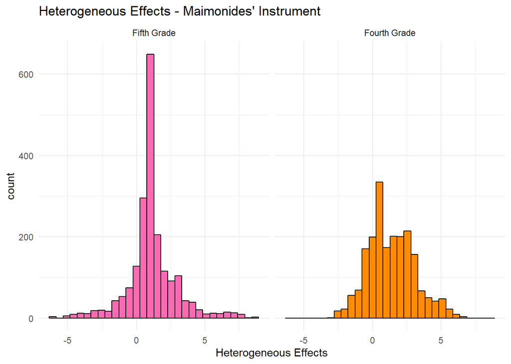

```r
ggplot(tau_hat_oob_maimonides,
       aes(x = predictions,
           fill = dataset)) +
  geom_histogram(colour = "black") +
  facet_wrap(~dataset) +
  scale_fill_manual(values = colour_pair) +
  labs(x = "Heterogeneous Effects",
       title = "Heterogeneous Effects - Maimonides' Instrument") +
  theme_minimal() +
  guides(fill = "none")
```

```r
N_obs <- nrow(tau_hat_oob_maimonides)
tau_hat_results_maimonides <- tau_hat_oob_maimonides %>%
  group_by(dataset) %>%
  arrange(predictions) %>%
  mutate(sigma_hat = sqrt(variance.estimates),
         prediction_lo = predictions - 1.96*sigma_hat,
         prediction_hi = predictions + 1.96*sigma_hat,
         prediction_lo_a = predictions - sigma_hat*qt(1-(0.05/2)/(n()^2), df = n()),
         prediction_hi_a = predictions + sigma_hat*qt(1-(0.05/2)/(n()^2), df = n()),
         t_stat = predictions / sigma_hat,
         critical_value = qt(0.95, N_obs - 4, lower.tail = FALSE),
         pval = pt(t_stat, df = N_obs - 13),
         pval_holm = p.adjust(pval, method = "holm", n = n()^2),
         reject_H0 = ifelse(pval_holm < 0.05, 1, 0),
         rank = row_number())
```

The relatively small dataset, where we know the saturated first stage test outperforms causal forest, is reflected in the huge confidence intervals when displaying the ranked $p$-values. Many of the estimated negative effects aren’t significantly different from 0 however this offers little comfort when there’s still such an inexplicable difference between test results.

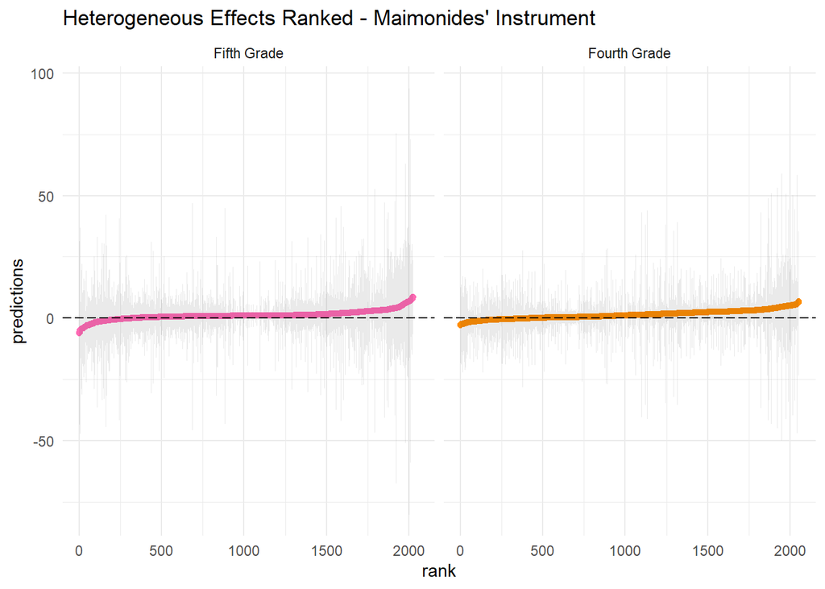

```r
tau_hat_results_maimonides %>%
  ggplot(aes(x = rank,
             y = predictions,
             ymin = prediction_lo_a,
             ymax = prediction_hi_a)) +
  geom_point(aes(colour = dataset)) +
  geom_ribbon(alpha = 0.1) +
  theme_minimal() +
  geom_hline(yintercept = 0, linetype = "longdash") +
  facet_wrap(~dataset) +
  scale_colour_manual(values = colour_pair) +
  labs(title = "Heterogeneous Effects Ranked - Maimonides' Instrument") +
  guides(colour = "none",
         fill = "none")
```

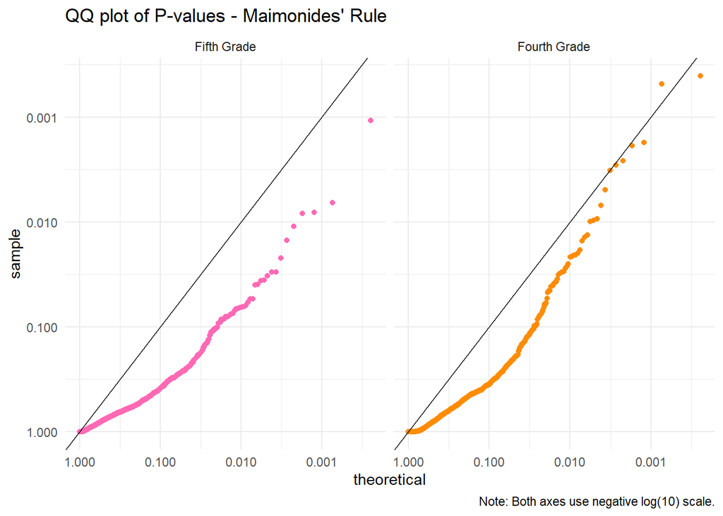

```r
tau_hat_results_maimonides %>%
  ggplot(aes(sample = pval, colour = dataset)) +
  stat_qq(distribution = qunif)  +
  geom_abline(intercept = 0, slope = 1) +
  theme_minimal() +
  scale_x_continuous(trans=negative_log_trans(10)) +
  scale_y_continuous(trans=negative_log_trans(10)) +
  labs(title = "QQ plot of P-values - Maimonides' Rule",
       caption = "Note: Both axes use negative log(10) scale.") +
  facet_wrap(~dataset) +
  scale_colour_manual(values = colour_pair) +
  guides(colour = "none",
         fill = "none")
```

## Autor Dorn Hanson

```r
ADH_matrix <- df_china %>%
  select(d_sh_empl_mfg,
         l_shind_manuf_cbp,
         starts_with("reg"),
         l_sh_popedu_c,
         l_sh_popfborn,
         l_sh_empl_f,
         l_sh_routine33,
         l_task_outsource,
         t2) %>%
  as.matrix()



forest_first_stage_ADH <- causal_forest(X = ADH_matrix,
                                        Y = df_china$d_tradeusch_pw,
                                        W = df_china$d_tradeotch_pw_lag,
                                        num.trees = 4000)

tau_hat_oob_ADH <- predict(forest_first_stage_ADH, estimate.variance = TRUE) %>%
  as_tibble() %>%
  mutate(dataset = "ADH")
```

Moving onto Autor, Dorn, and Hanson (2013)’s paper investigating imports and labour market outcomes leads to, yet again, wildly different conclusions to the saturated first stage test. However, in this case we find no evidence of defiers whereas before this was the most defiant dataset.

The distribution of heterogeneous effects is strictly positive with a long right tail. This is the smallest dataset in the empirical application of our tests so results should be interpreted with caution, especially with such a large divergence between tests.

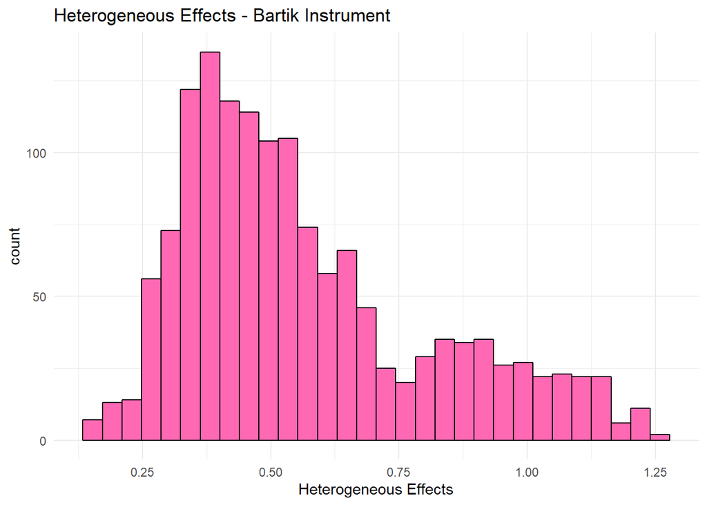

```r
ggplot(tau_hat_oob_ADH,
       aes(x = predictions, fill = dataset)) +
  geom_histogram(colour = "black") +
  scale_fill_manual(values = colour_pair) +
  labs(x = "Heterogeneous Effects",
       title = "Heterogeneous Effects - Bartik Instrument") +
  theme_minimal() +
  guides(fill = "none")
```

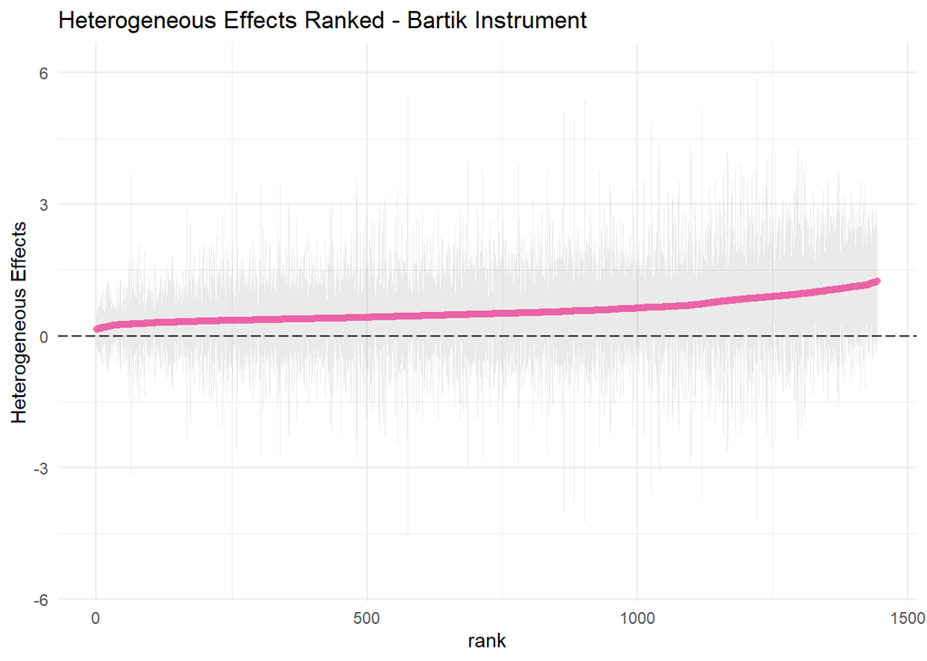

```r
N_obs <- nrow(tau_hat_oob_ADH)
tau_hat_results_ADH <- tau_hat_oob_ADH %>%
  arrange(predictions) %>%
  mutate(sigma_hat = sqrt(variance.estimates),
         prediction_lo = predictions - 1.96*sigma_hat,
         prediction_hi = predictions + 1.96*sigma_hat,
         prediction_lo_a = predictions - sigma_hat*qt(1-(0.05/2)/(n()^2), df = n()),
         prediction_hi_a = predictions + sigma_hat*qt(1-(0.05/2)/(n()^2), df = n()),
         t_stat = predictions / sigma_hat,
         critical_value = qt(0.95, N_obs - 12, lower.tail = FALSE),
         pval = pt(t_stat, df = N_obs - 13),
         pval_holm = p.adjust(pval, method = "holm", n = n()^2),
         reject_H0 = ifelse(pval_holm < 0.05, 1, 0),
         rank = row_number())

tau_hat_results_ADH %>%
  ggplot(aes(x = rank, y = predictions, ymin = prediction_lo_a, ymax = prediction_hi_a)) +
  geom_point(aes(colour = dataset)) +
  geom_ribbon(alpha = 0.1) +
  theme_minimal() +
  geom_hline(yintercept = 0, linetype = "longdash") +
  scale_colour_manual(values = colour_pair) +
  labs(y = "Heterogeneous Effects",
       title = "Heterogeneous Effects Ranked - Bartik Instrument") +
  guides(colour = "none",
         fill = "none")
```

The quantile-quantile plot shows no evidence of “curve back” as we’d expect in a dataset with no estimated defiers and the smallest $p$-value is safely insignificant at all reasonable testing levels.

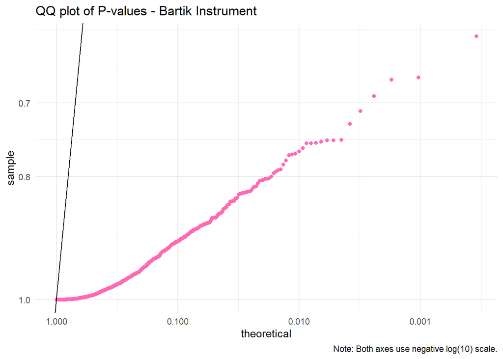

```r
tau_hat_results_ADH %>%
  ggplot(aes(sample = pval, colour = dataset)) +
  stat_qq(distribution = qunif)  +
  geom_abline(intercept = 0, slope = 1) +
  theme_minimal() +
  scale_x_continuous(trans=negative_log_trans(10)) +
  scale_y_continuous(trans=negative_log_trans(10)) +
  labs(title = "QQ plot of P-values - Bartik Instrument",
       caption = "Note: Both axes use negative log(10) scale.") +
  guides(colour = "none",
         fill = "none") +
  scale_colour_manual(values = colour_pair)
```

## Results

As we’ve seen, the honest causal forest estimates are an almost mirror opposite to the saturated first stage results. The only model with no detected defiers is Autor, Dorn, and Hanson (2013)’s whereas the model identifies a large number of defiers in every other dataset.

```r
tau_hat_results_all <- suppressWarnings(bind_rows(
  tau_hat_results %>%
    mutate(paper = "Same-Sex"),
  tau_hat_results_maimonides %>%
    mutate(paper = "Maimonides' Rule"),
  tau_hat_results_ADH %>%
    mutate(paper = "Shift-Share")
))

## TEST
#
# a <- first_stage_results %>%
#   group_by(paper,
#            dataset) %>%
#   filter(pval_one_neg == min(pval_one_neg))
#
# b <- first_stage_results %>%
#   group_by(paper,
#            dataset) %>%
#   filter(t_stat == min(t_stat))
#
# all_equal(a, b)






tau_hat_summary <- tau_hat_results_all %>%
  group_by(paper,
           dataset) %>%
  summarise(estimated_defiers = sum(ifelse(predictions < 0, 1, 0)),
            n = n(),
            pct_defiers = estimated_defiers / n,
         defier_pval = min(pval),
         defier_pval_adjusted = min(pval_holm),

         defier_tstat = min(t_stat)) %>%
  ungroup() %>%
  mutate(dataset = factor(dataset,
                          levels = c("1980",
                                     "1990",
                                     "Fourth Grade",
                                     "Fifth Grade",
                                     "ADH")))
colnames(tau_hat_summary) <- c("Paper",
                                   "Dataset",
                                   "Defiers",
                                   "N",
                                   "% Defier",
                                   "P-Value",
                                    "Adjusted P-Value",
                                   "T-Stat")


temp_df <- as_tibble(cbind(nms = names(tau_hat_summary), t(tau_hat_summary)))


colnames(temp_df) <- temp_df[2, ]

temp_df <- temp_df %>%
  filter(Dataset != "Paper" & Dataset != "Dataset") %>%
  mutate_at(vars(-Dataset),
            as.numeric)

temp_df %>%
  gt(rowname_col = "Dataset")  %>%
  tab_spanner(
    label = "Same-Sex",
    columns = vars(`1980`, `1990`)
  ) %>%
  tab_spanner(
    label = "Maimonides' Rule",
    columns = vars("Fourth Grade", "Fifth Grade")
  ) %>%
  tab_spanner(
    label = "Shift-Share",
    columns = vars("ADH")
  ) %>%
  fmt_number(
    columns = vars(`1990`,
                   `1980`,
                   `Fourth Grade`,
                   `Fifth Grade`,
                   `ADH`),
    decimals = 3,
    drop_trailing_zeros = TRUE
    ) %>%
  fmt_percent(
    columns = vars(`1980`,
                   `1990`,
                   `Fourth Grade`,
                   `Fifth Grade`,
                   `ADH`),
    rows = 3
  ) %>%
  tab_header(
    title = "Honest Causal Forest Results"
  )
```

Honest Causal Forest Results

|  | Maimonides' Rule |  | Same-Sex |  | Shift-Share |
| --- | --- | --- | --- | --- | --- |
|  | Fifth Grade | Fourth Grade | 1980 | 1990 | ADH |
| Defiers | 328 | 429 | 1,378 | 4,966 | 0 |
| N | 2,024 | 2,053 | 10,000 | 10,000 | 1,444 |
| % Defier | 16.21% | 20.90% | 13.78% | 49.66% | 0.00% |
| P-Value | 0.001 | 0 | 0.012 | 0 | 0.62 |
| Adjusted P-Value | 1 | 1 | 1 | 1 | 1 |
| T-Stat | -3.07 | -3.352 | -2.267 | -4.56 | 0.307 |

```r
rm(temp_df)
```

We know that the honest causal forest has an extreme test size problem when multiple comparisons aren’t adjusted for, therefore it’s hardly surprising that the model predicts a large number of defiers. Fortunately, after multiple comparison adjustments it’s clear that none of the estimated defiers are precisely estimated enough to reject the null hypothesis of no defiance.

The same-sex 1990 sample demonstrates just how important the adjustment process is - the $p$-value is corrected from a value insignificantly different from 0 at 4 decimal places to 1.

In conclusion, the honest causal forest test also fails to reject the null hypothesis of no defiers. However, model identification of defiers leads to very different conclusions to the saturated first stage test.

# Detected Defiers

In a bid to reconcile such a large difference in estimated defier proportions I now turn to some simple direct comparisons between model results concerning defier identification. First, we consider defiers detected by honest causal forest followed by the saturated first stage - I use data from Angrist and Lavy as well as Autor, Dorn and Hanson since these papers predominantly condition on continous rather than discrete covariates. Furthermore, since we only wish to compare model identification of defiers without performing inference I avoid discretising the data to increase power and improve comparability between the models.

## Maimonides’ Defiers

I plot instrument partial effects, from the saturated first stage model, on the $y$-axis against covariates on the $x$-axis; below this is a plot of heterogeneous treatment effects, estimated using honest causal forest, against covariates. Points in **black** indicate defiers detected by **honest causal forest**.

This exercise is useful for multiple reasons. Firstly, we can characterise common defier properties - for instance, the second plot suggests there are no defiers in schools with enrollment greater than 150, although admittedly there are few observations in this region. Overall, it seems that defiers are fairly evenly distributed across covariate values according to the honest causal forest.

Secondly, we can compare those identified as defiers by the causal forest with results from the saturated first stage. Promisingly, defiers estimated by the honest causal forest aren’t wildly different under the saturated first stage. That is, black points, the defiers, appear towards the lower end of the first plot with partial effects not far from 0.

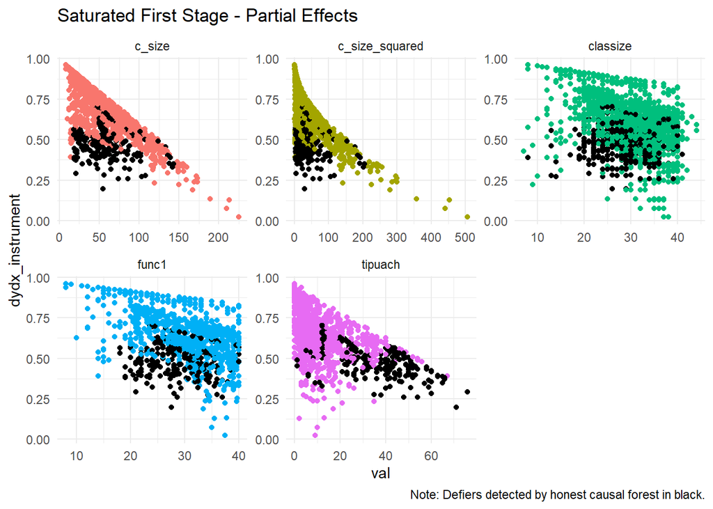

```r
first_stage_interactions_maim_4_continuous <-  df_final4_cleaned %>%
    select(classize,
         tipuach,
         c_size,
         func1) %>%
  run_first_stage_interactions_continuous(dataset = .,
                                    dependent_variable = "classize",
                                    instrument = "func1",
                                    vcov_func = vcovCL,
                                    cluster = df_final4_cleaned$classid,
                                    n_tiles = 3) %>%
  mutate(dataset = "Fourth Grade") %>%
  select(dydx_instrument, SE_dydx_instrument, pval_one_neg, dataset, dydx_lo, dydx_hi, t_stat, pval_neg_holm)




maim_4_plot <- df_final4_cleaned %>%
  select(classize,
         tipuach,
         c_size,
         c_size_squared,
         func1) %>%
  bind_cols(first_stage_interactions_maim_4_continuous) %>%
  gather(key, val, classize:func1)
maim_4_plot$prediction_rf <- tau_hat_oob_maim_4$predictions
maim_4_plot <- maim_4_plot %>%
  mutate(colour = ifelse(prediction_rf > 0, key, "Defier"),
         colour = factor(colour)) %>%
  mutate(colour = forcats::fct_relevel(colour, c("Defier")))

gg_color_hue <- function(n) {
  hues = seq(15, 375, length = n + 1)
  hcl(h = hues, l = 65, c = 100)[1:n]
}
my_cols <- gg_color_hue(5)
my_cols <- c("#000000", my_cols)

p <- maim_4_plot %>%
  ggplot(aes(x = val, y = dydx_instrument, colour = colour)) +
  geom_point() +
  facet_wrap(~key, scales = "free") +
  theme_minimal() +
  guides(colour = "none") +
  labs(title = "Saturated First Stage - Partial Effects",
       caption = "Note: Defiers detected by honest causal forest in black.") +
  scale_colour_manual(values = my_cols)



q <- maim_4_plot %>%
  ggplot(aes(x = val, y = prediction_rf, colour = colour)) +
  geom_point() +
  facet_wrap(~key, scales = "free") +
  theme_minimal() +
  guides(colour = "none") +
  labs(title = "Random Forest - Heterogeneous Effects",
       caption = "Note: Defiers detected by honest causal forest in black.") +
  scale_colour_manual(values = my_cols)




p
```

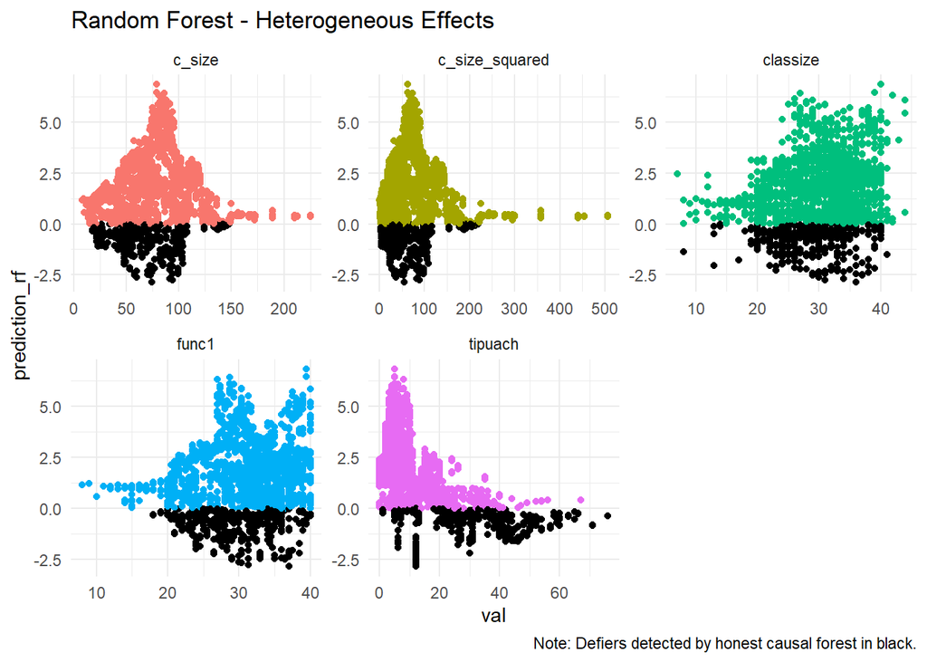

```r
q
```

Making any further comparisons between the plots above is difficult since they estimate essentially different features of the data. However, at first glance a big driver in test divergence appears to be non-linearity of the heterogeneous causal effects estimated.

## Autor Dorn Hanson Defiers

Moving onto Autor, Dorn and Hanson’s first stage results we instead display defiers detected by the **saturated first stage** in **purple**.

There seems to be a larger disparity between model results in Autor, Dorn and Hanson’s paper - some defiers detected by the saturated first stage have rather large, postive estimated heterogeneous treatment effects. In contrast to Angrist and Lavy’s results there seems to be a systematic pattern to defiance and little evidence of non-linearity. For example, defiers seem concentrated in areas with a low share of industrial manufacturing and proportion of college educated between 30-50%.

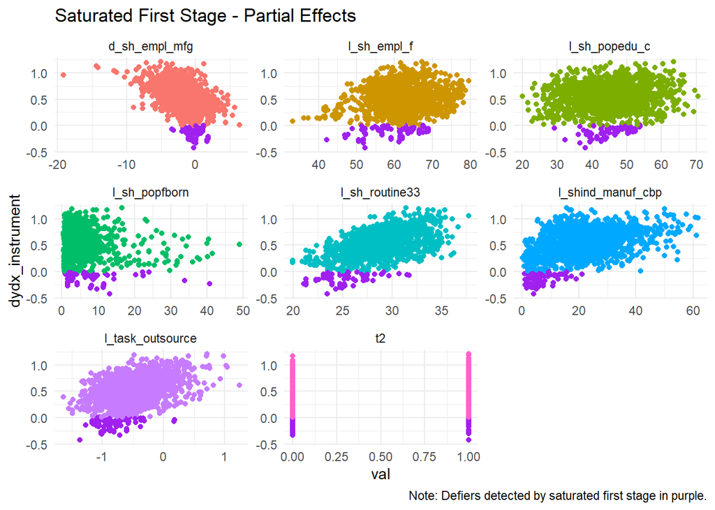

```r
first_stage_interactions_ADH_manu_continuous <- df_china %>%
  select(d_sh_empl_mfg,
         d_tradeusch_pw,
         d_tradeotch_pw_lag,
         l_shind_manuf_cbp,
         starts_with("reg"),
         l_sh_popedu_c,
         l_sh_popfborn,
         l_sh_empl_f,
         l_sh_routine33,
         l_task_outsource,
         t2) %>%
  run_first_stage_interactions_continuous(dataset = .,
                                    dependent_variable = "d_tradeusch_pw",
                                    instrument = "d_tradeotch_pw_lag",
                                    weights = df_china$timepwt48,
                                    vcov_func = vcovCL,
                                    cluster = df_china$statefip,
                                    n_tiles = 3) %>%
  mutate(dataset = "ADH") %>%
  select(dydx_instrument, SE_dydx_instrument, pval_one_neg,  dataset, dydx_lo, dydx_hi, t_stat, pval_neg_holm)

my_cols <- gg_color_hue(8)
my_cols <- c("purple", my_cols)

ADH_plot <- ADH_matrix %>%
  as_tibble() %>%
  select_at(vars(-contains("reg"))) %>%
  bind_cols(first_stage_interactions_ADH_manu_continuous) %>%
  gather(key,
         val,
         d_sh_empl_mfg:t2) %>%
  mutate(colour = ifelse(dydx_instrument > 0, key, "Defier"),
         colour = factor(colour)) %>%
  mutate(colour = forcats::fct_relevel(colour, c("Defier")))


ADH_plot$prediction_rf <- tau_hat_oob_ADH$predictions
p <- ADH_plot %>%
  ggplot(aes(x = val, y = dydx_instrument, colour = colour)) +
  facet_wrap(~key, scales = "free") +
  geom_point() +
  guides(colour = "none") +
  scale_colour_manual(values = my_cols) +
  theme_minimal() +
      labs(title = "Saturated First Stage - Partial Effects",
       caption = "Note: Defiers detected by saturated first stage in purple.")

q <- ADH_plot %>%
  ggplot(aes(x = val, y = prediction_rf, colour = colour)) +
  facet_wrap(~key, scales = "free") +
  geom_point() +
  scale_colour_manual(values = my_cols) +
  theme_minimal() +
  guides(colour = "none") +
      labs(title = "Random Forest - Heterogeneous Effects",
       caption = "Note: Defiers detected by saturated first stage in purple.")


p
```

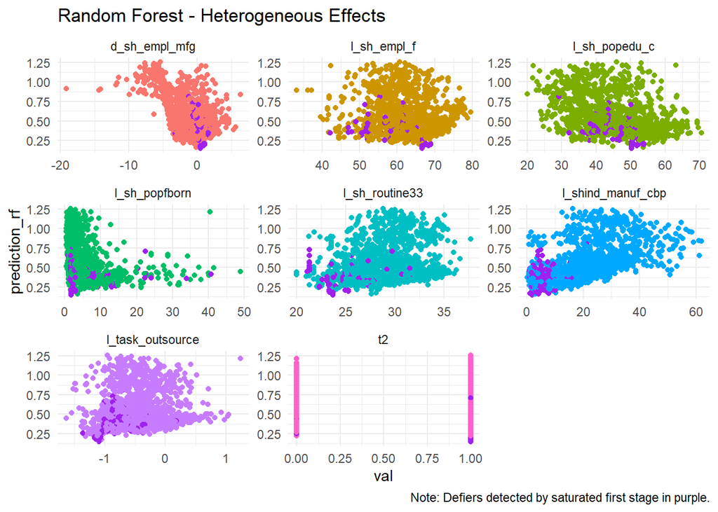

```r
q
```

Whilst not the central focus of this essay, identifiying defiers and those most likely to react negatively to a treatment is a crucial concern for policymakers concerned with welfare and equity. Further work, using a blend of traditional econometrics and machine learning techniques could potentially rationalise the difference in results found above. As it stands, it’s difficult to ex-post rationalise defier characteristics when both tests fail to agree on defier identification.

# Conclusion

In this essay I’ve presented two methods to detect defiers in datasets of interest to economists. Simulations show that both tests are powerful and correctly sized under a range of adverse data generating specifications and in the face of model misspecification, although both tests struggle to detect non-linear, heterogeneous defiance in smaller datasets.

Both tests produce similar results in simulations although model predictions of defier identity rarely agree. One possible explanation is that Simpson’s paradox is striking with a vengeance. Heterogeneous causal effects generated on aggregate at the observed subgroup level aren’t representative of individual heterogeneous effects and the causal forest method is picking this up whereas the saturated first stage model isn’t. However, I’m cautious of fully accepting the above interpretation - honest causal forest is a relatively new estimation strategy and its properties in real-world, applied settings still aren’t well understood. Occam’s razor would perhaps suggest that the first stage tests should be trusted most - without a doubt further exploration is required.

Furthermore, two of the datasets from labour economics considered are particularly small and graphing the heterogeneous effects suggest at least one of the datasets’ first stage displays non-linear properties therefore test power may be low.

Throughout the essay I’ve tried to present visualisations as a convenient tool to assist labour economists in detecting the presence of defiers in their own datasets. Stata’s `margins` command and R’s port of the command in the `margins` package make the saturated first stage test particularly easy to implement for future researchers. However, a major drawback of the tests presented here is a reliance on observed covariates - if a study only collects information on an outcome variable, the instrumented variable of interest and the instrument neither test will be appropriate.

The evidence upon taking the tests to the data is conclusive. Whilst the honest causal forest test predicts many defiers with a high degree of individual certainty, on aggregate after adjusting for multiple comparisons these defiers are no longer statistically significant. The saturated first stage method fails to reject the null hypothesis of no defiers and rarely predicts partial effect point estimates indicative of defiance. It seems reasonable to conclude that LATE estimates by Angrist and Evans; Angrist and Lavy; and Autor, Dorn and Hanson are well identified with no evidence of defiance.

# Appendix

## Angrist and Evans Replication

#### Table Two Summary Statistics

Trying to recreate table 2

```r
AE_90_summary <- df_90_final %>%
  summarise(children_ever_born = mean(fertil - 1),
            more_than_2 = mean(morekids),
            mean_boy_first = mean(boy1st),
            boy_2nd = mean(boy2nd),
            two_boys = mean(boys2),
            two_girls = mean(girls2),
            samesex = mean(samesex),
            age = mean(m_age),
            worked = mean(worked_m),
            weeks = mean(week89m),
            hrs_wk = mean(hour89m),
            labour_income_mum = mean(income_m),
            labour_income_dad = mean(income_d, na.rm = TRUE),
            fam_income = mean(fam_inc),
            mean_non_wife = mean(nonmoi)) %>%
  gather(term, mean_90)

AE_80_summary <- df_80_final %>%
    summarise(children_ever_born = mean(fertil - 1),
            more_than_2 = mean(morekids),
            mean_boy_first = mean(boy1st),
            boy_2nd = mean(boy2nd),
            two_boys = mean(boys2),
            two_girls = mean(girls2),
            samesex = mean(samesex),
            age = mean(m_age),
            worked = mean(worked_m),
            weeks = mean(weeksm),
            hrs_wk = mean(hoursm),
            labour_income_mum = mean(income_m),
            labour_income_dad = mean(income_d, na.rm = TRUE),
            fam_income = mean(fam_inc),
            mean_non_wife = mean(nonmoi)) %>%
  gather(term, mean_80)

AE_summary <- inner_join(AE_80_summary, AE_90_summary, by = "term") %>%
  knitr::kable(digits = 3)
AE_summary
```

| term | mean_80 | mean_90 |
| --- | --- | --- |
| children_ever_born | 2.509 | 2.495 |
| more_than_2 | 0.381 | 0.370 |
| mean_boy_first | 0.514 | 0.513 |
| boy_2nd | 0.512 | 0.511 |
| two_boys | 0.266 | 0.264 |
| two_girls | 0.239 | 0.240 |
| samesex | 0.505 | 0.504 |
| age | 30.388 | 30.434 |
| worked | 0.528 | 0.667 |
| weeks | 19.020 | 26.388 |
| hrs_wk | 16.705 | 22.690 |
| labour_income_mum | 6249.913 | 9870.505 |
| labour_income_dad | 18532.177 | 29197.906 |
| fam_income | 47658.291 | 44317.127 |
| mean_non_wife | 41649.272 | 34882.804 |

#### Regression Results

Recreating Table 5

```r
table_5_models_90 <- c("worked_m",
  "week89m",
  "hour89m",
  "income_m",
  "log(fam_inc)") %>%
  map(~(
  paste0(., " ~ morekids | samesex") %>%
  as.formula() %>%
  ivreg(., data = df_90_final)))

table_5_models_80 <- c("worked_m",
  "weeksm",
  "hoursm",
  "income_m",
  "log(fam_inc)") %>%
  map(~(
  paste0(., " ~ morekids | samesex") %>%
  as.formula() %>%
  ivreg(., data = df_80_final)))

stargazer(table_5_models_80,
          omit = "Constant",
          title = "WALD ESTIMATES OF LABOR-SUPPLY MODELS 1980 DATA - REPLICATED",header = FALSE,type = "html",
          dep.var.labels = c("Worked",
                            "Weeks",
                            "Hours",
                            "Income",
                            "Family Income"))
```

**WALD ESTIMATES OF LABOR-SUPPLY MODELS 1980 DATA - REPLICATED**

|  | *Dependent variable:* |  |  |  |  |
| --- | --- | --- | --- | --- | --- |
|  | Worked | Weeks | Hours | Income | Family Income |
|  | (1) | (2) | (3) | (4) | (5) |
| morekids | -0.134*** | -6.149*** | -5.499*** | -1,601.982*** | -0.039 |
|  | (0.029) | (1.283) | (1.080) | (600.143) | (0.062) |
| Observations | 255,010 | 255,010 | 255,010 | 255,010 | 255,010 |
| R<sup>2</sup> | 0.012 | 0.014 | 0.008 | 0.011 | 0.002 |
| Adjusted R<sup>2</sup> | 0.012 | 0.014 | 0.008 | 0.011 | 0.002 |
| Residual Std. Error (df = 255008) | 0.496 | 21.713 | 18.269 | 10,154.510 | 1.043 |
| *Note:* | p<0.1; p<0.05; p<0.01 |  |  |  |  |

```r
stargazer(table_5_models_90,
          omit = "Constant",
          title = "WALD ESTIMATES OF LABOR-SUPPLY MODELS 1990 DATA - REPLICATED",header = FALSE,type = "html",
          dep.var.labels = c("Worked",
                            "Weeks",
                            "Hours",
                            "Income",
                            "Family Income"))
```

**WALD ESTIMATES OF LABOR-SUPPLY MODELS 1990 DATA - REPLICATED**

|  | *Dependent variable:* |  |  |  |  |
| --- | --- | --- | --- | --- | --- |
|  | Worked | Weeks | Hours | Income | Family Income |
|  | (1) | (2) | (3) | (4) | (5) |
| morekids | -0.087*** | -4.947*** | -3.757*** | -1,736.529** | -0.127* |
|  | (0.024) | (1.165) | (0.974) | (688.333) | (0.073) |
| Observations | 380,007 | 380,007 | 380,007 | 380,007 | 380,007 |
| R<sup>2</sup> | 0.015 | 0.021 | 0.016 | 0.014 | 0.006 |
| Adjusted R<sup>2</sup> | 0.015 | 0.021 | 0.016 | 0.014 | 0.006 |
| Residual Std. Error (df = 380005) | 0.468 | 22.632 | 18.934 | 13,377.480 | 1.428 |
| *Note:* | p<0.1; p<0.05; p<0.01 |  |  |  |  |

```r
rm(table_5_models_80,
   table_5_models_90)
```

Now table 6

```r
create_model_formula <- function(dependent_var){
  model <- as.formula(paste0(dependent_var, "~ morekids + m_age + boy1st + boy2nd + black_m + hisp_m + other_race_m | samesex +  m_age + boy1st + boy2nd + black_m + hisp_m + other_race_m"))
  return(model)
}

table_6_models_80 <- c("worked_m",
  "weeksm",
  "hoursm",
  "income_m",
  "log(fam_inc)") %>%
  map(~(create_model_formula(.) %>%
          ivreg(data = df_80_final)))


table_6_models_90 <- c("worked_m",
                    "week89m",
                    "hour89m",
                    "income_m",
                    "log(fam_inc)") %>%
  map(~(create_model_formula(.) %>%
          ivreg(data = df_90_final)))

stargazer(table_6_models_80,
          keep = "morekidsTRUE",
          title = "2SLS ESTIMATES OF LABOR-SUPPLY MODELS USING 1980 CENSUS DATA - REPLICATION",
          notes = "Age at first birth omitted since I can't seem to find it.",
          dep.var.labels = c("Worked",
                            "Weeks",
                            "Hours",
                            "Income",
                            "Family Income"),
          type = "html")
```

**2SLS ESTIMATES OF LABOR-SUPPLY MODELS USING 1980 CENSUS DATA - REPLICATION**

|  | *Dependent variable:* |  |  |  |  |
| --- | --- | --- | --- | --- | --- |
|  | Worked | Weeks | Hours | Income | Family Income |
|  | (1) | (2) | (3) | (4) | (5) |
| morekids | -0.124*** | -5.566*** | -5.118*** | -1,336.928** | -0.029 |
|  | (0.029) | (1.247) | (1.053) | (581.528) | (0.060) |
| Observations | 255,010 | 255,010 | 255,010 | 255,010 | 255,010 |
| R<sup>2</sup> | 0.028 | 0.044 | 0.030 | 0.045 | 0.031 |
| Adjusted R<sup>2</sup> | 0.028 | 0.044 | 0.030 | 0.045 | 0.031 |
| Residual Std. Error (df = 255002) | 0.492 | 21.385 | 18.064 | 9,976.483 | 1.028 |
| *Note:* | p<0.1; p<0.05; p<0.01 |  |  |  |  |
|  | Age at first birth omitted since I can’t seem to find it. |  |  |  |  |

```r
stargazer(table_6_models_90, keep = "morekidsTRUE",
          title = "2SLS ESTIMATES OF LABOR-SUPPLY MODELS USING 1990 CENSUS DATA - REPLICATION",
          notes = "Age at first birth omitted since I can't seem to find it.",
          dep.var.labels = c("Worked",
                            "Weeks",
                            "Hours",
                            "Income",
                            "Family Income"),
          type = "html")
```

**2SLS ESTIMATES OF LABOR-SUPPLY MODELS USING 1990 CENSUS DATA - REPLICATION**

|  | *Dependent variable:* |  |  |  |  |
| --- | --- | --- | --- | --- | --- |
|  | Worked | Weeks | Hours | Income | Family Income |
|  | (1) | (2) | (3) | (4) | (5) |
| morekids | -0.092*** | -5.318*** | -3.936*** | -1,937.590*** | -0.123* |
|  | (0.024) | (1.148) | (0.969) | (676.699) | (0.070) |
| Observations | 380,007 | 380,007 | 380,007 | 380,007 | 380,007 |
| R<sup>2</sup> | 0.030 | 0.049 | 0.026 | 0.047 | 0.088 |
| Adjusted R<sup>2</sup> | 0.030 | 0.049 | 0.026 | 0.047 | 0.088 |
| Residual Std. Error (df = 379999) | 0.464 | 22.311 | 18.833 | 13,150.230 | 1.368 |
| *Note:* | p<0.1; p<0.05; p<0.01 |  |  |  |  |
|  | Age at first birth omitted since I can’t seem to find it. |  |  |  |  |

```r
rm(table_6_models_80, table_6_models_90)
```

## Replicating OLS

```r
## Grade 5
col_1 <- lm(avgverb ~ classize, data = df_final5_cleaned)
col_2 <- lm(avgverb ~ classize + tipuach, data = df_final5_cleaned)
col_3 <- lm(avgverb ~ classize + tipuach + c_size, data = df_final5_cleaned)
col_4 <- lm(avgmath ~ classize, data = df_final5_cleaned)
col_5 <- lm(avgmath ~ classize + tipuach, data = df_final5_cleaned)
col_6 <- lm(avgmath ~ classize + tipuach + c_size, data = df_final5_cleaned)
## Grade 4
col_7 <- lm(avgverb ~ classize, data = df_final4_cleaned)
col_8 <- lm(avgverb ~ classize + tipuach, data = df_final4_cleaned)
col_9 <- lm(avgverb ~ classize + tipuach + c_size, data = df_final4_cleaned)
col_10 <- lm(avgmath ~ classize, data = df_final4_cleaned)
col_11 <- lm(avgmath ~ classize + tipuach, data = df_final4_cleaned)
col_12 <- lm(avgmath ~ classize + tipuach + c_size, data = df_final4_cleaned)

SEs <- list(col_1,
            col_2,
            col_3,
            col_4,
            col_5,
            col_6,
            col_7,
            col_8,
            col_9,
            col_10,
            col_11,
            col_12) %>%
  map(~(vcovHAC(.) %>%
          diag() %>%
          sqrt))

stargazer(col_1,
          col_2,
          col_3,
          col_4,
          col_5,
          col_6,
          col_7,
          col_8,
          col_9,
          col_10,
          col_11,
          col_12,
          se = SEs,
          omit.table.layout = "sn",
          type = "html",
          omit = "Constant",
          dep.var.labels = c("English Comprehension",
                             "Maths",
                             "English Comprehension",
                             "Maths"),
          column.labels = c("Grade 5",
                            "Grade 4"),
          column.separate = c(6, 6),
          initial.zero = FALSE,
          notes = "HAC standard errors used instead of Moulton factor adjustment.")
```

|  | *Dependent variable:* |  |  |  |  |  |  |  |  |  |  |  |
| --- | --- | --- | --- | --- | --- | --- | --- | --- | --- | --- | --- | --- |
|  | English Comprehension |  |  | Maths |  |  | English Comprehension |  |  | Maths |  |  |
|  | Grade 5 |  |  |  |  |  | Grade 4 |  |  |  |  |  |
|  | (1) | (2) | (3) | (4) | (5) | (6) | (7) | (8) | (9) | (10) | (11) | (12) |
| classize | .221*** | -.031 | -.025 | .322*** | .076* | .019 | .141*** | -.053* | -.040 | .221*** | .055 | .009 |
|  | (.035) | (.027) | (.033) | (.044) | (.039) | (.045) | (.037) | (.028) | (.033) | (.041) | (.036) | (.040) |
| tipuach |  | -.350*** | -.351*** |  | -.340*** | -.332*** |  | -.339*** | -.341*** |  | -.289*** | -.281*** |
|  |  | (.015) | (.016) |  | (.021) | (.021) |  | (.016) | (.017) |  | (.019) | (.020) |
| c_size |  |  | -.002 |  |  | .017** |  |  | -.004 |  |  | .014** |
|  |  |  | (.006) |  |  | (.008) |  |  | (.006) |  |  | (.007) |

```r
rm(col_1,
   col_2,
   col_3,
   col_4,
   col_5,
   col_6,
   col_7,
   col_8,
   col_9,
   col_10,
   col_11,
   col_12
   )
```

## Replicating IV

```r
## Grade 5


iv_maim_verb_full_5 <- ivreg(avgverb ~ classize + tipuach + c_size + c_size_squared | func1 + tipuach + c_size + c_size_squared, data = df_final5_cleaned)
iv_maim_math_full_5 <- ivreg(avgmath ~ classize + tipuach + c_size + c_size_squared | func1 + tipuach + c_size + c_size_squared, data = df_final5_cleaned)

iv_maim_verb_disc_5 <- ivreg(avgverb ~ classize + tipuach + c_size + c_size_squared | func1 + tipuach + c_size + c_size_squared, data = df_final5_cleaned %>% filter(disc == 1))
iv_maim_math_disc_5 <- ivreg(avgmath ~ classize + tipuach + c_size + c_size_squared | func1 + tipuach + c_size + c_size_squared, data = df_final5_cleaned %>% filter(disc == 1))


## Grade 4

iv_maim_verb_full_4 <- ivreg(avgverb ~ classize + tipuach + c_size + c_size_squared | func1 + tipuach + c_size + c_size_squared, data = df_final4_cleaned)
iv_maim_math_full_4 <- ivreg(avgmath ~ classize + tipuach + c_size + c_size_squared | func1 + tipuach + c_size + c_size_squared, data = df_final4_cleaned)

iv_maim_verb_disc_4 <- ivreg(avgverb ~ classize + tipuach + c_size + c_size_squared | func1 + tipuach + c_size + c_size_squared, data = df_final4_cleaned %>% filter(disc == 1))
iv_maim_math_disc_4 <- ivreg(avgmath ~ classize + tipuach + c_size + c_size_squared | func1 + tipuach + c_size + c_size_squared, data = df_final4_cleaned %>% filter(disc == 1))




SEs_IV_5 <- list(
  iv_maim_verb_full_5,
  iv_maim_math_full_5,
  iv_maim_verb_disc_5,
  iv_maim_math_disc_5
) %>%
  map(~(vcovHAC(.) %>%
          diag() %>%
          sqrt))
stargazer(iv_maim_verb_full_5,
          iv_maim_math_full_5,
          iv_maim_verb_disc_5,
          iv_maim_math_disc_5,
          se = SEs_IV_5,
          column.labels = c("Full Sample", "Discontinuity Sample"),
          column.separate = c(2, 2),
          type = "html",
          title = "IV Maimonides Rule Fifth Grade",
          notes = "HAC standard errors used instead of Moulton factor adjustment.")
```

**IV Maimonides Rule Fifth Grade**

|  | *Dependent variable:* |  |  |  |
| --- | --- | --- | --- | --- |
|  | avgverb | avgmath | avgverb | avgmath |
|  | Full Sample |  | Discontinuity Sample |  |
|  | (1) | (2) | (3) | (4) |
| classize | -0.263*** | -0.264** | -0.599*** | -0.490** |
|  | (0.093) | (0.120) | (0.225) | (0.246) |
| tipuach | -0.369*** | -0.350*** | -0.457*** | -0.423*** |
|  | (0.017) | (0.023) | (0.051) | (0.066) |
| c_size | 0.013 | 0.063* | 0.126 | 0.284** |
|  | (0.026) | (0.036) | (0.114) | (0.132) |
| c_size_squared | 0.004 | -0.010 | -0.044 | -0.124* |
|  | (0.010) | (0.014) | (0.060) | (0.075) |
| Constant | 86.129*** | 75.993*** | 92.499*** | 74.510*** |
|  | (1.755) | (2.334) | (4.624) | (6.698) |
| Observations | 2,019 | 2,018 | 471 | 471 |
| R<sup>2</sup> | 0.343 | 0.229 | 0.232 | 0.201 |
| Adjusted R<sup>2</sup> | 0.341 | 0.228 | 0.225 | 0.194 |
| Residual Std. Error | 6.236 (df = 2014) | 8.435 (df = 2013) | 7.200 (df = 466) | 9.161 (df = 466) |
| *Note:* | p<0.1; p<0.05; p<0.01 |  |  |  |
|  | HAC standard errors used instead of Moulton factor adjustment. |  |  |  |

```r
SEs_IV_4 <- list(
  iv_maim_verb_full_4,
  iv_maim_math_full_4,
  iv_maim_verb_disc_4,
  iv_maim_math_disc_4
) %>%
  map(~(vcovHAC(.) %>%
          diag() %>%
          sqrt))
stargazer(iv_maim_verb_full_4,
          iv_maim_math_full_4,
          iv_maim_verb_disc_4,
          iv_maim_math_disc_4,
          se = SEs_IV_4,
          column.labels = c("Full Sample", "Discontinuity Sample"),
          column.separate = c(2, 2),
          type = "html",
          title = "IV Maimonides Rule Fourth Grade",
          notes = "HAC standard errors used instead of Moulton factor adjustment.")
```

**IV Maimonides Rule Fourth Grade**

|  | *Dependent variable:* |  |  |  |
| --- | --- | --- | --- | --- |
|  | avgverb | avgmath | avgverb | avgmath |
|  | Full Sample |  | Discontinuity Sample |  |
|  | (1) | (2) | (3) | (4) |
| classize | -0.074 | -0.033 | -0.131 | 0.033 |
|  | (0.069) | (0.085) | (0.131) | (0.167) |
| tipuach | -0.346*** | -0.284*** | -0.350*** | -0.291*** |
|  | (0.017) | (0.020) | (0.040) | (0.048) |
| c_size | -0.040* | 0.007 | -0.057 | -0.016 |
|  | (0.022) | (0.028) | (0.097) | (0.116) |
| c_size_squared | 0.021** | 0.006 | 0.045 | 0.023 |
|  | (0.009) | (0.012) | (0.061) | (0.074) |
| Constant | 81.036*** | 72.775*** | 82.406*** | 70.967*** |
|  | (1.521) | (1.923) | (4.635) | (6.562) |
| Observations | 2,049 | 2,049 | 415 | 415 |
| R<sup>2</sup> | 0.312 | 0.206 | 0.281 | 0.184 |
| Adjusted R<sup>2</sup> | 0.311 | 0.205 | 0.274 | 0.177 |
| Residual Std. Error | 6.635 (df = 2044) | 7.818 (df = 2044) | 6.671 (df = 410) | 8.244 (df = 410) |
| *Note:* | p<0.1; p<0.05; p<0.01 |  |  |  |
|  | HAC standard errors used instead of Moulton factor adjustment. |  |  |  |

```r
rm(SEs_IV_4,
   SEs_IV_5,
   SEs,
   iv_maim_math_disc_4,
   iv_maim_math_full_4,
   iv_maim_verb_disc_4,
   iv_maim_verb_full_4,
   iv_maim_math_disc_5,
   iv_maim_math_full_5,
   iv_maim_verb_disc_5,
   iv_maim_verb_full_5)
```

```r
save.image("C:/Users/edjee/Dropbox/Ed/cached_run.RData")
```

# References

Angrist, Joshua D., and William N. Evans. 1998. “Children and Their Parents’ Labor Supply: Evidence from Exogenous Variation in Family Size.” *The American Economic Review* 88 (3). American Economic Association: 450–77. http://www.jstor.org/stable/116844.

Angrist, and Jorn-Steffen Pischke. 2009. *Mostly Harmless Econometrics: An Empiricist’s Companion*. 1st ed. Princeton University Press. https://EconPapers.repec.org/RePEc:pup:pbooks:8769.

Athey, Susan, and Guido Imbens. 2016. “Recursive Partitioning for Heterogeneous Causal Effects.” *Proceedings of the National Academy of Sciences* 113 (27). National Academy of Sciences: 7353–60. doi:10.1073/pnas.1510489113.

Athey, Susan, Julie Tibshirani, and Stefan Wager. 2016. “Generalized Random Forests.” *arXiv E-Prints*, October, arXiv:1610.01271.

Autor, David H., David Dorn, and Gordon H. Hanson. 2013. “The China Syndrome: Local Labor Market Effects of Import Competition in the United States.” *American Economic Review* 103 (6): 2121–68. doi:10.1257/aer.103.6.2121.

Benjamini, Yoav, and Yosef Hochberg. 1995. “Controlling the False Discovery Rate: A Practical and Powerful Approach to Multiple Testing.” *Journal of the Royal Statistical Society. Series B (Methodological)* 57 (1). [Royal Statistical Society, Wiley]: 289–300. http://www.jstor.org/stable/2346101.

Chernozhukov, Victor, Sokbae Lee, and Adam M. Rosen. 2009. “Intersection Bounds: Estimation and Inference.” *arXiv E-Prints*, July, arXiv:0907.3503.

Gelman, Andrew. 2018. “Statistical Modeling, Causal Inference, and Social Science.” *Statistical Modeling, Causal Inference, and Social Science:* https://statmodeling.stat.columbia.edu/2018/03/15/need-16-times-sample-size-estimate-interaction-estimate-main-effect/.

Holm, Sture. 1979. “A Simple Sequentially Rejective Multiple Test Procedure.” *Scandinavian Journal of Statistics* 6 (2). [Board of the Foundation of the Scandinavian Journal of Statistics, Wiley]: 65–70. http://www.jstor.org/stable/4615733.

Imbens, Guido W., and Joshua D. Angrist. 1994. “Identification and Estimation of Local Average Treatment Effects.” *Econometrica* 62 (2). [Wiley, Econometric Society]: 467–75. http://www.jstor.org/stable/2951620.

Kitagawa, Toru. 2015. “A Test for Instrument Validity.” *Econometrica* 83 (5): 2043–63. doi:10.3982/ECTA11974.

Lavy, Victor, and Joshua D. Angrist. 1999. “Using Maimonides’ Rule to Estimate the Effect of Class Size on Scholastic Achievement*.” *The Quarterly Journal of Economics* 114 (2): 533–75. doi:10.1162/003355399556061.

Mourifie, Ismael, and Yuanyuan Wan. 2017. “Testing Local Average Treatment Effect Assumptions.” *The Review of Economics and Statistics* 99 (2): 305–13. doi:10.1162/REST\_a\_00622.

Shaffer, Juliet. 1995. “Multiple Hypothesis Testing.” *Annual Review of Psychology* 46 (January): 561–84. doi:10.1146/annurev.ps.46.020195.003021.

Wager, Stefan, and Susan Athey. 2015. “Estimation and Inference of Heterogeneous Treatment Effects using Random Forests.” *arXiv E-Prints*, October, arXiv:1510.04342.

[^1]: For simplicity the rest of the essay assumes $D_{1i} - D_{0i} \geq 0$ unless explicitly stated otherwise.
[^2]: Or equivalently, taking differences in the binary case.
[^3]: Which is perhaps approximating $N \times (N-1)$ adjustments - verifying this rigorously is, again, computationally prohibitive.
[^4]: I use Cholesky decomposition to generate p.s.d $\Sigma = LL'$ by simulating entries of $L$ drawn from $U(-1, 1)$